# 🎨 Colors and Advertisements 📢

2025-05-09

# Introduction

An exploration of how the overall rating of advertisements varies with color schemes, timing and the use of primary colors, using data I collected from social media ads (such as Instagram). I recorded this information through a Google Form I created, then compiled the responses into a Google Spreadsheet for analysis.

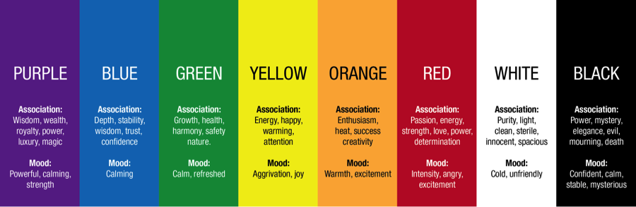

## Overall rating depending on primary colours graph

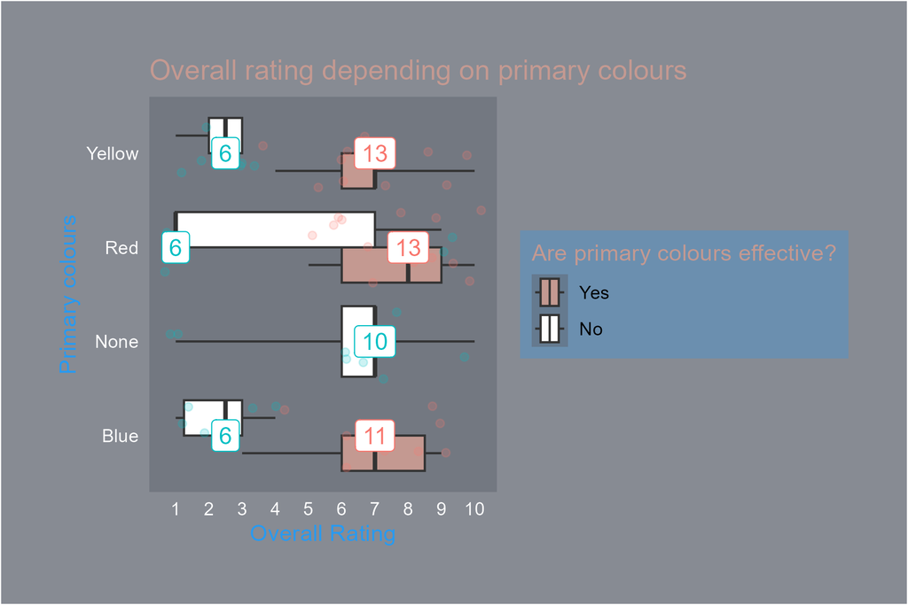

My first graph was on how overall rating depends on primary colours and how many reponses does each dependency (i.e. yes/no) have. This is because I thought it is interesting to see how the gap differs between colours (i.e. is there one colour where it does not matter if it is effective or not). What I found was that if no primary colours are involved, the average overall rating is still high. I found this suprising as I thought red and yellow are key colours to use in advertisements as our eyes catch red, orange and yellow the fastest yet even without these colours, many advertisements were still overall rated quite high.

## Overall rating depending on hour graph

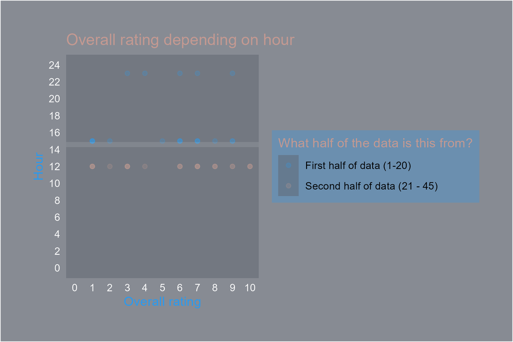

My second graph was on seeing how overall rating depend on the hour I submitted my data. This is because I thought it is interesting to see if me being more awake change the overall rating for the worse or better. What I found was that the earlier I did the data in the day, the more variable it was but it lead to overall higher ratings as I did not enter any tens until I did it in the morning. This was interesting as I expected it to be higher in the later evening since I was more rushing it in comparison to the morning where I had more time to analyse the colours used.

## Overall rating depending on colour schemes

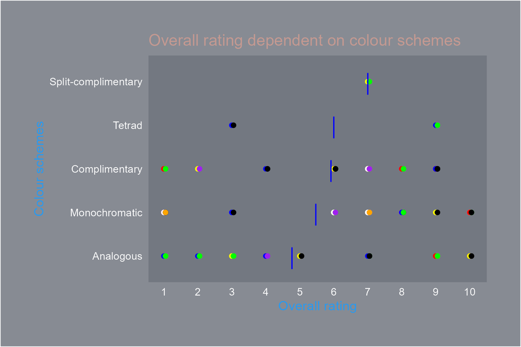

My third graph was on seeing how overall rating depends on colour schemes. This is because I thought it is interesting to see if specific colour schemes mean that there is a higher rating and if the colours used play into that. What I found was that split complimentary had the highest overall rating and that tetrad was either a hit or a miss. This was interesting as I thought more complicated colour schemes would have a lower rating since they are more complicated to understand when compared to a monochromatic colour scheme which only has one colour to focus on in comparison, but monochromatic colour scheme was actually one of the lowest rated ones.

# In conclusion

Overall, I learned that my overall rating improves when I complete the form earlier and that overall rating is not affected by primary colours as much as I thought it does, but complicated colour schemes improves overall rating contrary to what I originally thought.